# Anova e Regressão Linear

Gabriella Saraiva, Matheus Silva, Yannis Pontushka, Bruno Friedrich, André Oliveira e Fernando Liu

2023-09-13

# 1 Contextualização

Para o presente trabalho, foi selecionado um conjunto de dados que inclui informações sobre o preço médio de carros no Brasil. Este conjunto de dados contém detalhes de quase 300 mil veículos, abrangendo as seguintes categorias: Marca, Tamanho do Motor em cm³, Preço Médio do Carro em Reais no ano de 2022, Idade do Carro e Tipo de Combustível. Em primeiro momento, os dados originais passaram por um processo de redução em duas etapas: primeiro, foram escolhidas as cinco marcas de carros mais populares e, em seguida, uma amostra aleatória de 5000 carros dessas marcas foi extraída para a análise.

Optamos pelo Preço Médio do carro como a variável dependente nas análises. Em essência, nosso interesse é compreender como o preço do carro é afetado pelas demais variáveis. Para atingir esse objetivo, conduzimos uma análise de variância (ANOVA), onde consideramos a marca como uma variável qualitativa. Posteriormente, realizamos uma regressão linear, empregando a idade do carro como uma variável quantitativa. Por fim, efetuamos uma avaliação dos resíduos para assegurar a validade e a significância da amostra.

# 2 Carregamento dos pacotes

```r
library(dplyr)
library(car)
library(ggplot2)
library(knitr)
library(kableExtra)
library(htmltools)
library(openxlsx)
library(DT)
library(htmltools)
library(rstatix)
library(emmeans)
library(rcompanion)
library(dlookr)
library(lmtest)
library(tidyverse)
library(ggpubr)
library(xtable)
```

# 3 Leitura e visualização do banco de dados

```
## Rows: 5,000
## Columns: 5
## $ Marca            <chr> "Fiat", "Ford", "GM - Chevrolet", "Fiat", "Ford", "Me…
## $ Tamanho.do.Motor <dbl> 1.0, 3.9, 2.0, 1.0, 1.5, 2.2, 2.8, 2.5, 2.8, 2.0, 3.9…
## $ Preço.Médio.BRL  <int> 15982, 27451, 22535, 130616, 44055, 170872, 149207, 3…
## $ Combustível      <chr> "Gasoline", "Diesel", "Gasoline", "Gasoline", "Gasoli…
## $ Idade            <int> 18, 34, 19, 0, 7, 5, 4, 23, 19, 19, 15, 7, 1, 25, 32,…
```

```r
tabela <- datatable(head(dados, 10),
                    options = list(dom = 't', paging = FALSE),
                    rownames = FALSE)
tabela %>%
  formatStyle(columns = names(dados)[-1], textAlign = "right")
```

| Marca | Tamanho do Motor | Preço Médio BRL | Combustível | Idade |
| --- | --- | --- | --- | --- |
| Fiat | 1 | 15982 | Gasoline | 18 |
| Ford | 3.9 | 27451 | Diesel | 34 |
| GM - Chevrolet | 2 | 22535 | Gasoline | 19 |
| Fiat | 1 | 130616 | Gasoline | 0 |
| Ford | 1.5 | 44055 | Gasoline | 7 |
| Mercedes-Benz | 2.2 | 170872 | Diesel | 5 |
| GM - Chevrolet | 2.8 | 149207 | Diesel | 4 |
| GM - Chevrolet | 2.5 | 38797 | Diesel | 23 |
| Fiat | 2.8 | 42594 | Diesel | 19 |
| Ford | 2 | 21327 | Gasoline | 19 |

# 4 Anova

Uma análise ANOVA foi conduzida para investigar a influência da marca (variável independente) do carro nos preços médios (variável dependente) dos automóveis das cinco principais marcas no mercado automobilístico brasileiro. Essa análise tem como objetivo avaliar se a marca de um veículo desempenha um papel significativo na determinação dos preços médios, com base nos dados disponíveis.

```r
anova_carros <- aov(`Preço Médio BRL` ~ Marca, data = dados)

summary(anova_carros)
```

```
##               Df    Sum Sq   Mean Sq F value Pr(>F)
## Marca          4 2.555e+13 6.389e+12     233 <2e-16 ***
## Residuals   4995 1.369e+14 2.742e+10
## ---
## Signif. codes:  0 '***' 0.001 '**' 0.01 '*' 0.05 '.' 0.1 ' ' 1
```

O resultado indica que a variável ‘Marca’ tem um impacto altamente significativo nos preços médios dos carros das top 5 marcas no Brasil. O valor F extremamente alto (233) e o valor p praticamente zero (<2e-16) indicam que as diferenças nas médias de preços entre essas marcas são altamente significativas do ponto de vista estatístico.

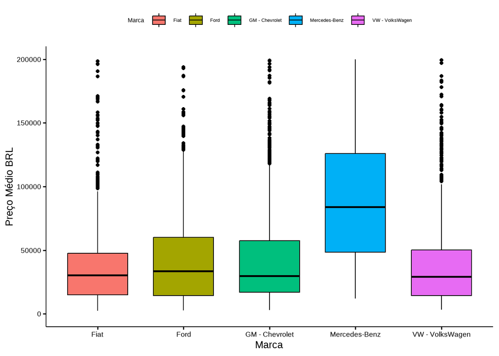

```r
dados %>%
  ggboxplot(x = "Marca", y = "Preço Médio BRL", fill = "Marca") +
  scale_y_continuous(limits = c(0, 200000), breaks = seq(0, 200000, by = 50000)) +
  theme(axis.title.x = element_text(size = 20),
        axis.title.y = element_text(size = 20),
        axis.text.x = element_text(size = 14),
        axis.text.y = element_text(size = 14))
```

> Comparação dos preços médios de carros das diferentes marcas, com um foco específico em preços até 200.000 BRL.

## 4.1 Resíduos

Para a análise de resíduos foi utilizado o teste de Levene. O teste de Levene pode ser usado como uma ferramenta para analisar a homogeneidade das variâncias dos resíduos na análise. Ele ajuda a verificar se a premissa da homogeneidade das variâncias (também conhecida como homocedasticidade) é atendida.

```
## Levene's Test for Homogeneity of Variance (center = median)
##         Df F value    Pr(>F)
## group    4  141.09 < 2.2e-16 ***
##       4995
## ---
## Signif. codes:  0 '***' 0.001 '**' 0.01 '*' 0.05 '.' 0.1 ' ' 1
```

Com base nos resultados, rejeitaríamos a hipótese nula (H0) de igualdade das variâncias. Isso sugere que há evidências estatísticas de que pelo menos uma das marcas tem uma variância significativamente diferente em relação às outras marcas em termos de preço médio de carros. Isso pode ter implicações na escolha do método estatístico apropriado para análise posterior, especialmente se estivermos considerando métodos sensíveis à homogeneidade de variância, como a ANOVA.

## 4.2 Verificando Normalidade

### 4.2.1 Verificando Normalidade dos Preço

A variável dependente (“Preço Médio BRL”) deve apresentar distribuição aproximadamente normal dentro de cada grupo. Os grupos aqui serão formados pela variável independente (“Marca”). A normalidade será avaliada pelo teste de Shapiro-Wilk.

```r
dados %>% group_by(Marca) %>%
  shapiro_test(Preco)
```

```
## # A tibble: 5 × 4
##   Marca           variable statistic        p
##   <chr>           <chr>        <dbl>    <dbl>
## 1 Fiat            Preco        0.766 1.66e-36
## 2 Ford            Preco        0.721 2.84e-36
## 3 GM - Chevrolet  Preco        0.650 4.65e-43
## 4 Mercedes-Benz   Preco        0.426 9.33e-43
## 5 VW - VolksWagen Preco        0.742 2.70e-39
```

Adicionalmente, empregamos o método plot_normality para avaliar a distribuição da variável. Esse método, parte da biblioteca ‘dlookr’ em R, oferece uma análise visual da normalidade dos dados, usando gráficos como histogramas e Q-Q plot.

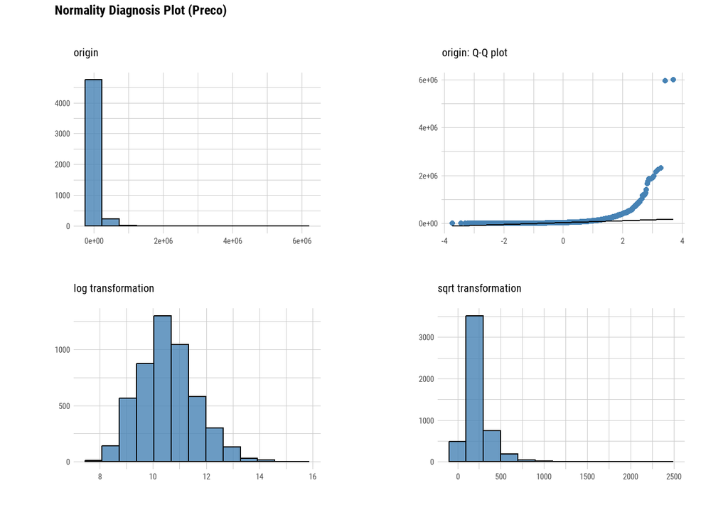

```r
plot_normality(dados, x = "Preco")
```

Os resultados dos testes Shapiro-Wilk e a análise do gráficos indicam que a distribuição dos preços dos carros para todas as marcas (Fiat, Ford, GM - Chevrolet, Mercedes-Benz e VW - VolksWagen) não segue uma distribuição normal.

### 4.2.2 Verificando Normalidade dos Resíduos

```r
shapiro.test(anova_carros$residuals)
```

```
##
##  Shapiro-Wilk normality test
##
## data:  anova_carros$residuals
## W = 0.31854, p-value < 2.2e-16
```

O resultado indica que o valor de W (0.31854) está consideravelmente distante de 1, o que sugere que os resíduos não apresentam uma distribuição normal. Além disso, o valor p é praticamente zero (p < 2.2e-16), o que significa que existem evidências estatisticamente significativas para rejeitar a hipótese nula de normalidade. Ou seja, os resíduos não seguem uma distribuição normal.

> **Conclusão**: Embora o primeiro resultado indique que a variável ‘Marca’ tem um impacto altamente significativo nos preços médios dos carros, a falta de normalidade nos preços de cada marca pode apontar para a presença de outros fatores ou peculiaridades nos dados que também estão afetando os preços. Portanto, uma ANOVA **não é viável** como modelo de análise para este caso.

# 5 Regressão Linear

## 5.1 Descrição dos Dados

Para dar início à nossa análise, foram coletados dados introdutórios sobre as variáveis que compõem o nosso conjunto de dados. Estas variáveis incluem a ‘Marca’ do veículo, o ‘Tamanho do Motor’, o ‘Preço Médio’ em BRL (Reais Brasileiros) e o tipo de ‘Combustível’ utilizado.

```r
diagnose(dados)
```

```
## # A tibble: 5 × 6
##   variables        types  missing_count missing_percent unique_count unique_rate
##   <chr>            <chr>          <int>           <dbl>        <int>       <dbl>
## 1 Marca            chara…             0               0            5      0.001
## 2 Tamanho do Motor numer…             0               0           43      0.0086
## 3 Preço Médio BRL  integ…             0               0         4868      0.974
## 4 Combustível      chara…             0               0            3      0.0006
## 5 Idade            integ…             0               0           39      0.0078
```

```r
diagnose_numeric(dados)
```

```
##          variables    min       Q1       mean  median      Q3       max zero
## 1 Tamanho do Motor    0.7     1.60     2.1489     1.8     2.4       6.5    0
## 2  Preço Médio BRL 2515.0 18106.25 75377.6164 36681.5 72500.0 5980566.0    0
## 3            Idade    0.0     8.00    15.7968    14.0    23.0      38.0  150
##   minus outlier
## 1     0     619
## 2     0     507
## 3     0       0
```

```r
summary(dados)
```

```
##     Marca           Tamanho do Motor Preço Médio BRL   Combustível
##  Length:5000        Min.   :0.700    Min.   :   2515   Length:5000
##  Class :character   1st Qu.:1.600    1st Qu.:  18106   Class :character
##  Mode  :character   Median :1.800    Median :  36682   Mode  :character
##                     Mean   :2.149    Mean   :  75378
##                     3rd Qu.:2.400    3rd Qu.:  72500
##                     Max.   :6.500    Max.   :5980566
##      Idade
##  Min.   : 0.0
##  1st Qu.: 8.0
##  Median :14.0
##  Mean   :15.8
##  3rd Qu.:23.0
##  Max.   :38.0
```

```r
desc <- describe(dados)
```

## 5.2 Análise de Regressão Linear

Uma análise de Regressão Linear foi conduzida para investigar a influência da idade (variável independente) nos preços médios (variável dependente) dos automóveis no mercado automobilístico brasileiro. O objetivo desta análise é avaliar se a idade de um veículo desempenha um papel significativo na determinação dos preços médios, com base nos dados disponíveis.

Primeiramente, é uma boa ideia dar uma olhada no gráfico de dispersão que relaciona a Idade e o Preço Médio BRL dos carros. Isso nos permite visualizar como os dados estão distribuídos em relação a essas duas variáveis.

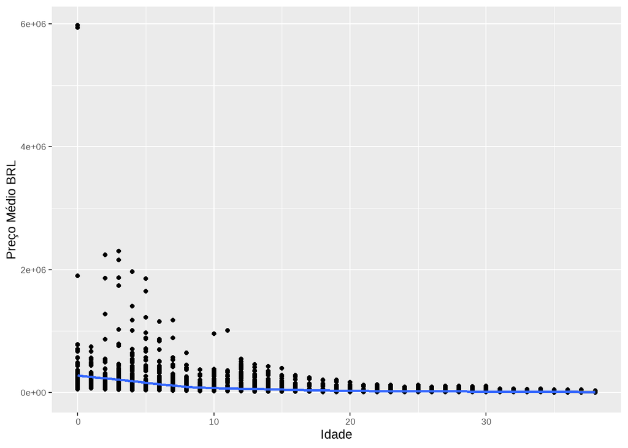

```r
ggplot(dados)+
  aes(x=Idade,y=`Preço Médio BRL`)+
    geom_point()+
    geom_smooth()+
  theme(axis.title.x = element_text(size = 20),
        axis.title.y = element_text(size = 20),
        axis.text.x = element_text(size = 14),
        axis.text.y = element_text(size = 14))
```

Além disso, o gráfico de pontos a seguir oferece uma perspectiva da relação entre o ‘Preço Médio’ dos veículos e sua ‘Idade’. No eixo horizontal, temos a ‘Idade’ dos carros, expressa em anos. Enquanto no eixo vertical, encontramos o ‘Preço Médio’ em BRL (Reais Brasileiros), que representa o valor médio de venda dos automóveis. Conforme seguimos da esquerda para a direita no gráfico, torna-se evidente que, à medida que um carro envelhece, seu preço médio tende a diminuir. Essa tendência indica que carros mais antigos geralmente têm valores de venda mais baixos.

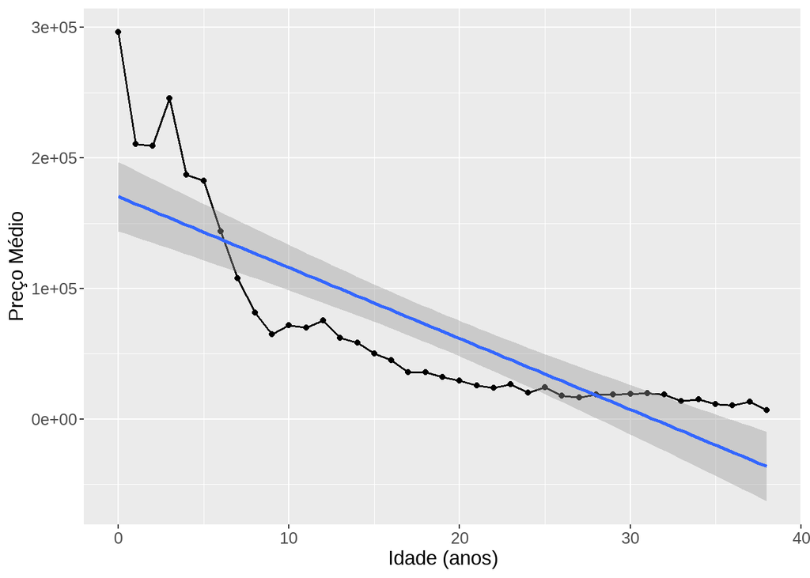

```r
resumo <- dados %>% group_by(Idade) %>%
  summarize(`Preço Médio BRL` = mean(`Preço Médio BRL`),
            erro_padrao = sd(`Preço Médio BRL`) / sqrt(n()))

ggplot(resumo, aes(x = Idade, y = `Preço Médio BRL`)) +
  geom_line(size = 0.6) +
  geom_point() +
  geom_errorbar(aes(ymin = `Preço Médio BRL` - erro_padrao, ymax = `Preço Médio BRL` + erro_padrao), width = 0.2) +
  ylab("Preço Médio") +
  xlab("Idade (anos)") +
  geom_smooth(method=lm) +
  theme(axis.title.x = element_text(size = 25),
        axis.title.y = element_text(size = 25),
        axis.text.x = element_text(size = 20),
        axis.text.y = element_text(size = 20))
```

```r
m<-lm(`Preço Médio BRL` ~ Idade, data = dados)
summary(m)
```

```
##
## Call:
## lm(formula = `Preço Médio BRL` ~ Idade, data = dados)
##
## Residuals:
##     Min      1Q  Median      3Q     Max
## -121412  -59137  -22686   16023 5809205
##
## Coefficients:
##             Estimate Std. Error t value Pr(>|t|)
## (Intercept) 171360.8     4643.2   36.91   <2e-16 ***
## Idade        -6076.1      251.1  -24.20   <2e-16 ***
## ---
## Signif. codes:  0 '***' 0.001 '**' 0.01 '*' 0.05 '.' 0.1 ' ' 1
##
## Residual standard error: 170600 on 4998 degrees of freedom
## Multiple R-squared:  0.1048, Adjusted R-squared:  0.1047
## F-statistic: 585.4 on 1 and 4998 DF,  p-value: < 2.2e-16
```

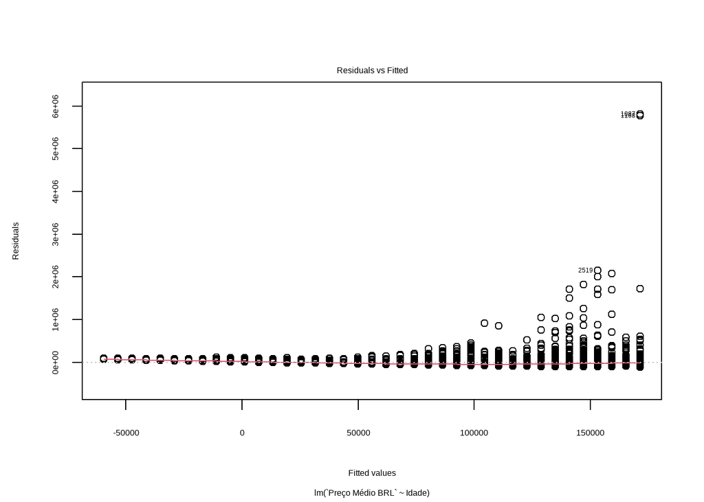

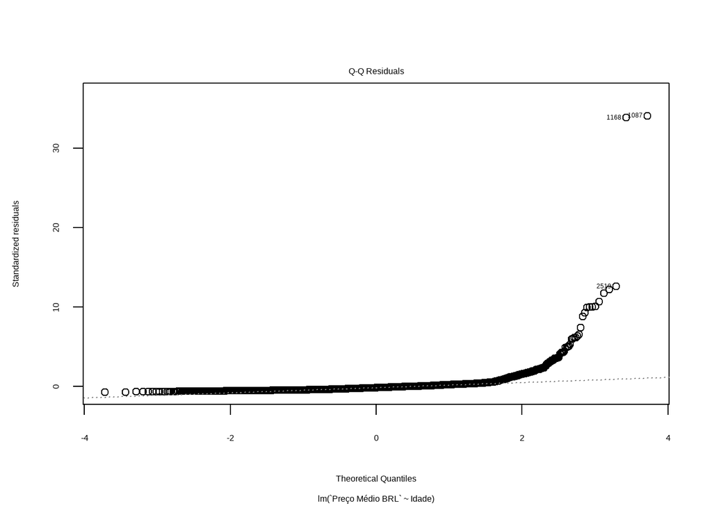

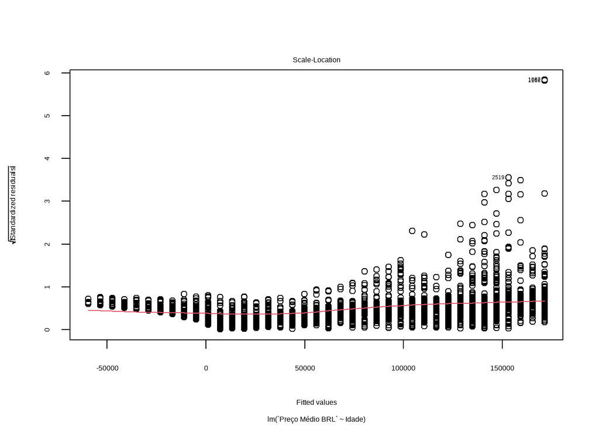

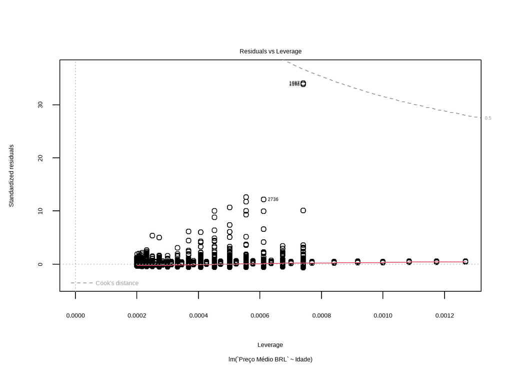

```r
plot(m)
```

### 5.2.1 Resíduos

Para a análise de resíduos, foi empregado o teste de Breusch-Pagan (BP). O teste de Breusch-Pagan é comumente utilizado como uma ferramenta para analisar a homogeneidade das variâncias dos resíduos em modelos de regressão. Ele auxilia na verificação se a suposição de homocedasticidade (igualdade de variâncias dos resíduos) é satisfeita.

```r
bptest(m)
```

```
##
##  studentized Breusch-Pagan test
##
## data:  m
## BP = 16.117, df = 1, p-value = 5.953e-05
```

O resultado observado - valor de p baixo (geralmente abaixo de um limite de significância, como 0,05) - sugere que você pode rejeitar a hipótese nula. Isso significa que há evidências de heteroscedasticidade, ou seja, a variância dos erros não é constante.

#### 5.2.1.1 Normalidade dos Resíduos

```r
shapiro.test(m$residuals)
```

```
##
##  Shapiro-Wilk normality test
##
## data:  m$residuals
## W = 0.29111, p-value < 2.2e-16
```

O resultado indica que o valor de W (0.29111) está consideravelmente distante de 1, o que sugere que os resíduos não apresentam uma distribuição normal. Além disso, o valor p é praticamente zero (p < 2.2e-16), o que significa que existem evidências estatisticamente significativas para rejeitar a hipótese nula de normalidade. Ou seja, os resíduos não seguem uma distribuição normal.

#### 5.2.1.2 Autocorelação do Resíduos

Por fim, foi utilizado o teste de Durbin-Watson para avaliar a presença de autocorrelação nos resíduos de um modelo de regressão. Em outras palavras, indica se o modelo não está incluindo alguma variável preditora útil ou que deveria incluir um componente temporar, como uma moda ou indicador sazonal.

```r
dwtest(m)
```

```
##
##  Durbin-Watson test
##
## data:  m
## DW = 1.9837, p-value = 0.2827
## alternative hypothesis: true autocorrelation is greater than 0
```

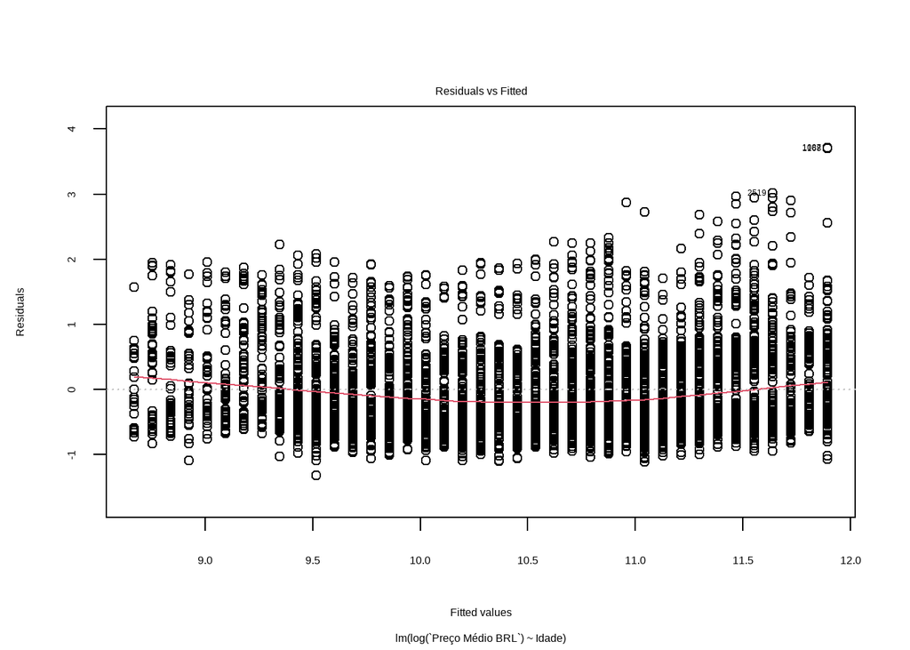

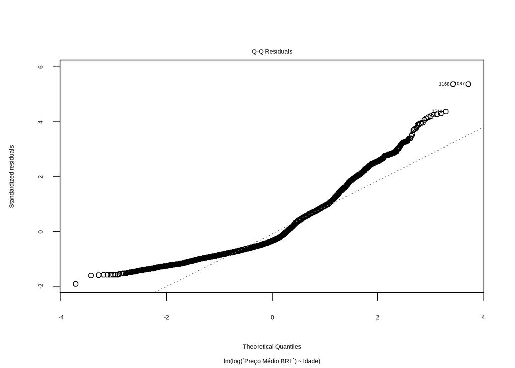

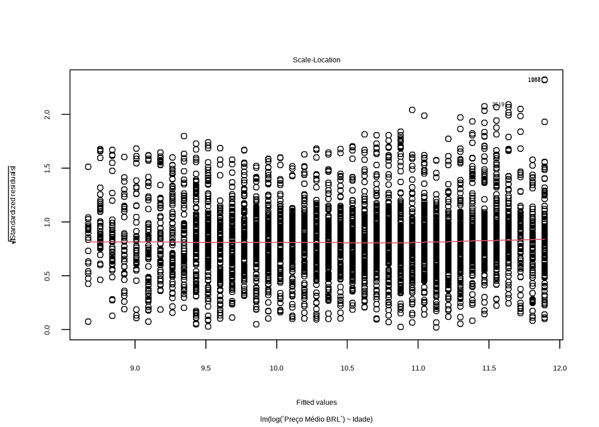

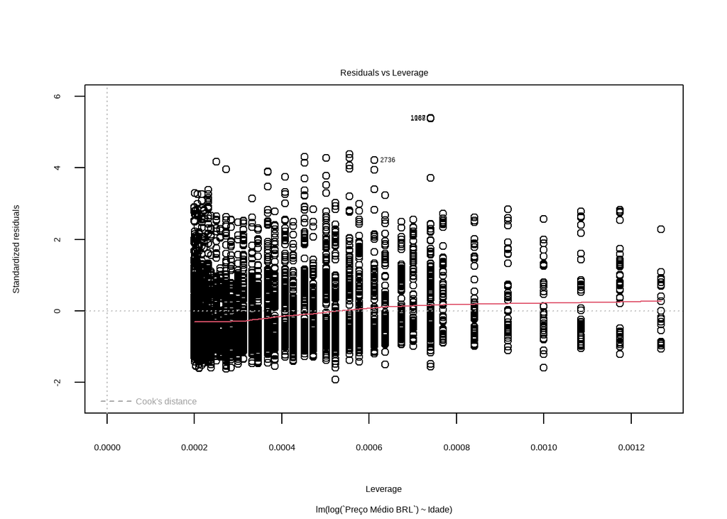

```r
m<-lm(log(`Preço Médio BRL`) ~ Idade, data = dados)
plot(m)
```

```r
bptest(m)
```

```
##
##  studentized Breusch-Pagan test
##
## data:  m
## BP = 2.3803, df = 1, p-value = 0.1229
```

```r
shapiro.test(m$residuals)
```

```
##
##  Shapiro-Wilk normality test
##
## data:  m$residuals
## W = 0.90079, p-value < 2.2e-16
```

```r
dwtest(m)
```

```
##
##  Durbin-Watson test
##
## data:  m
## DW = 1.941, p-value = 0.01841
## alternative hypothesis: true autocorrelation is greater than 0
```